# Air Quality Trends & Insights in India (2015–2020)

```python
import pandas as pd
import matplotlib.pyplot as plt
import seaborn as sns
import numpy as np

df = pd.read_csv("city_day.csv")
df
```

|  | City | Date | PM2.5 | PM10 | NO | NO2 | NOx | NH3 | CO | SO2 | O3 | Benzene | Toluene | Xylene | AQI | AQI_Bucket |
| --- | --- | --- | --- | --- | --- | --- | --- | --- | --- | --- | --- | --- | --- | --- | --- | --- |
| 0 | Ahmedabad | 2015-01-01 | NaN | NaN | 0.92 | 18.22 | 17.15 | NaN | 0.92 | 27.64 | 133.36 | 0.00 | 0.02 | 0.00 | NaN | NaN |
| 1 | Ahmedabad | 2015-01-02 | NaN | NaN | 0.97 | 15.69 | 16.46 | NaN | 0.97 | 24.55 | 34.06 | 3.68 | 5.50 | 3.77 | NaN | NaN |
| 2 | Ahmedabad | 2015-01-03 | NaN | NaN | 17.40 | 19.30 | 29.70 | NaN | 17.40 | 29.07 | 30.70 | 6.80 | 16.40 | 2.25 | NaN | NaN |
| 3 | Ahmedabad | 2015-01-04 | NaN | NaN | 1.70 | 18.48 | 17.97 | NaN | 1.70 | 18.59 | 36.08 | 4.43 | 10.14 | 1.00 | NaN | NaN |
| 4 | Ahmedabad | 2015-01-05 | NaN | NaN | 22.10 | 21.42 | 37.76 | NaN | 22.10 | 39.33 | 39.31 | 7.01 | 18.89 | 2.78 | NaN | NaN |
| ... | ... | ... | ... | ... | ... | ... | ... | ... | ... | ... | ... | ... | ... | ... | ... | ... |
| 29526 | Visakhapatnam | 2020-06-27 | 15.02 | 50.94 | 7.68 | 25.06 | 19.54 | 12.47 | 0.47 | 8.55 | 23.30 | 2.24 | 12.07 | 0.73 | 41.0 | Good |
| 29527 | Visakhapatnam | 2020-06-28 | 24.38 | 74.09 | 3.42 | 26.06 | 16.53 | 11.99 | 0.52 | 12.72 | 30.14 | 0.74 | 2.21 | 0.38 | 70.0 | Satisfactory |
| 29528 | Visakhapatnam | 2020-06-29 | 22.91 | 65.73 | 3.45 | 29.53 | 18.33 | 10.71 | 0.48 | 8.42 | 30.96 | 0.01 | 0.01 | 0.00 | 68.0 | Satisfactory |
| 29529 | Visakhapatnam | 2020-06-30 | 16.64 | 49.97 | 4.05 | 29.26 | 18.80 | 10.03 | 0.52 | 9.84 | 28.30 | 0.00 | 0.00 | 0.00 | 54.0 | Satisfactory |
| 29530 | Visakhapatnam | 2020-07-01 | 15.00 | 66.00 | 0.40 | 26.85 | 14.05 | 5.20 | 0.59 | 2.10 | 17.05 | NaN | NaN | NaN | 50.0 | Good |

29531 rows × 16 columns

```python
df.shape
```

```
(29531, 16)
```

```python
df.info()
```

```
<class 'pandas.core.frame.DataFrame'>
RangeIndex: 29531 entries, 0 to 29530
Data columns (total 16 columns):
 #   Column      Non-Null Count  Dtype
---  ------      --------------  -----
 0   City        29531 non-null  object
 1   Date        29531 non-null  object
 2   PM2.5       24933 non-null  float64
 3   PM10        18391 non-null  float64
 4   NO          25949 non-null  float64
 5   NO2         25946 non-null  float64
 6   NOx         25346 non-null  float64
 7   NH3         19203 non-null  float64
 8   CO          27472 non-null  float64
 9   SO2         25677 non-null  float64
 10  O3          25509 non-null  float64
 11  Benzene     23908 non-null  float64
 12  Toluene     21490 non-null  float64
 13  Xylene      11422 non-null  float64
 14  AQI         24850 non-null  float64
 15  AQI_Bucket  24850 non-null  object
dtypes: float64(13), object(3)
memory usage: 3.6+ MB
```

```python
df.describe()
```

|  | PM2.5 | PM10 | NO | NO2 | NOx | NH3 | CO | SO2 | O3 | Benzene | Toluene | Xylene | AQI |
| --- | --- | --- | --- | --- | --- | --- | --- | --- | --- | --- | --- | --- | --- |
| count | 24933.000000 | 18391.000000 | 25949.000000 | 25946.000000 | 25346.000000 | 19203.000000 | 27472.000000 | 25677.000000 | 25509.000000 | 23908.000000 | 21490.000000 | 11422.000000 | 24850.000000 |
| mean | 67.450578 | 118.127103 | 17.574730 | 28.560659 | 32.309123 | 23.483476 | 2.248598 | 14.531977 | 34.491430 | 3.280840 | 8.700972 | 3.070128 | 166.463581 |
| std | 64.661449 | 90.605110 | 22.785846 | 24.474746 | 31.646011 | 25.684275 | 6.962884 | 18.133775 | 21.694928 | 15.811136 | 19.969164 | 6.323247 | 140.696585 |
| min | 0.040000 | 0.010000 | 0.020000 | 0.010000 | 0.000000 | 0.010000 | 0.000000 | 0.010000 | 0.010000 | 0.000000 | 0.000000 | 0.000000 | 13.000000 |
| 25% | 28.820000 | 56.255000 | 5.630000 | 11.750000 | 12.820000 | 8.580000 | 0.510000 | 5.670000 | 18.860000 | 0.120000 | 0.600000 | 0.140000 | 81.000000 |
| 50% | 48.570000 | 95.680000 | 9.890000 | 21.690000 | 23.520000 | 15.850000 | 0.890000 | 9.160000 | 30.840000 | 1.070000 | 2.970000 | 0.980000 | 118.000000 |
| 75% | 80.590000 | 149.745000 | 19.950000 | 37.620000 | 40.127500 | 30.020000 | 1.450000 | 15.220000 | 45.570000 | 3.080000 | 9.150000 | 3.350000 | 208.000000 |
| max | 949.990000 | 1000.000000 | 390.680000 | 362.210000 | 467.630000 | 352.890000 | 175.810000 | 193.860000 | 257.730000 | 455.030000 | 454.850000 | 170.370000 | 2049.000000 |

```python
df.isnull().sum()
```

```
City              0
Date              0
PM2.5          4598
PM10          11140
NO             3582
NO2            3585
NOx            4185
NH3           10328
CO             2059
SO2            3854
O3             4022
Benzene        5623
Toluene        8041
Xylene        18109
AQI            4681
AQI_Bucket     4681
dtype: int64
```

```python
len(df['City'].unique())
```

```
26
```

```python
df['City'].value_counts()
```

```
City
Ahmedabad             2009
Delhi                 2009
Mumbai                2009
Bengaluru             2009
Lucknow               2009
Chennai               2009
Hyderabad             2006
Patna                 1858
Gurugram              1679
Visakhapatnam         1462
Amritsar              1221
Jorapokhar            1169
Jaipur                1114
Thiruvananthapuram    1112
Amaravati              951
Brajrajnagar           938
Talcher                925
Kolkata                814
Guwahati               502
Coimbatore             386
Shillong               310
Chandigarh             304
Bhopal                 289
Ernakulam              162
Kochi                  162
Aizawl                 113
Name: count, dtype: int64
```

```python
df['AQI_Bucket'].value_counts()
```

```
AQI_Bucket
Moderate        8829
Satisfactory    8224
Poor            2781
Very Poor       2337
Good            1341
Severe          1338
Name: count, dtype: int64
```

```python
df['Date'] = pd.to_datetime(df['Date'], errors='coerce')
df = df.sort_values(by=['City', 'Date']).reset_index(drop=True)
```

```python
pollutants = [
    'PM2.5', 'PM10', 'NO', 'NO2', 'NOx', 'NH3',
    'CO', 'SO2', 'O3', 'Benzene', 'Toluene', 'Xylene',
]

missing_counts = df[pollutants].isnull().sum()
print("Missing values per pollutant:\n", missing_counts)
```

```
Missing values per pollutant:
 PM2.5       4598
PM10       11140
NO          3582
NO2         3585
NOx         4185
NH3        10328
CO          2059
SO2         3854
O3          4022
Benzene     5623
Toluene     8041
Xylene     18109
dtype: int64
```

```python
print(df[['NH3', 'Toluene', 'Xylene', 'AQI']].corr())
```

```
              NH3   Toluene    Xylene       AQI
NH3      1.000000  0.013227 -0.019813  0.252019
Toluene  0.013227  1.000000  0.421432  0.279992
Xylene  -0.019813  0.421432  1.000000  0.165532
AQI      0.252019  0.279992  0.165532  1.000000
```

```python
columns_drop = ['NH3', 'Toluene', 'Xylene']
df = df.drop(columns=columns_drop)
```

```python
# df = df.dropna(subset=['PM2.5', 'AQI', 'AQI_Bucket'])
```

```python
df.shape
```

```
(29531, 13)
```

```python
pollutants = [
    'PM2.5', 'NO', 'NO2', 'NOx',
    'CO', 'SO2', 'O3', 'Benzene','PM10'

]
missing_counts= df[pollutants].isnull().sum()
missing_counts
```

```
PM2.5       4598
NO          3582
NO2         3585
NOx         4185
CO          2059
SO2         3854
O3          4022
Benzene     5623
PM10       11140
dtype: int64
```

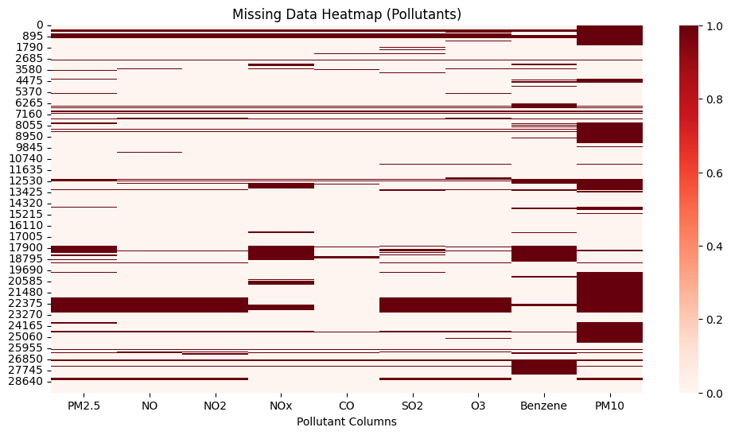

```python
plt.figure(figsize=(12, 6))
sns.heatmap(df[pollutants].isnull(), cmap='Reds')
plt.title('Missing Data Heatmap (Pollutants)')
plt.xlabel('Pollutant Columns')
plt.show()
```

```python
missing_percent = (df.isnull().sum() / len(df)) * 100
print(missing_percent[['PM2.5', 'NO', 'NO2', 'NOx',
    'CO', 'SO2', 'O3', 'Benzene','PM10']])
```

```
PM2.5      15.570079
NO         12.129626
NO2        12.139785
NOx        14.171549
CO          6.972334
SO2        13.050692
O3         13.619586
Benzene    19.041008
PM10       37.723071
dtype: float64
```

```python
columns_to_interpolate = ['PM2.5','PM10', 'NO', 'NO2', 'NOx',
    'CO', 'SO2', 'O3', 'Benzene']
df[columns_to_interpolate] = df[columns_to_interpolate].interpolate(method='linear')
```

```python
missing_counts= df[pollutants].isnull().sum()
missing_counts
```

```
PM2.5        27
NO            0
NO2           0
NOx           0
CO            0
SO2           0
O3            0
Benzene       0
PM10       1594
dtype: int64
```

```python
# df['AQI'] = df['AQI'].fillna(method='bfill')
```

```python
df['PM2.5'].isna().sum()
```

```
27
```

```python
df['PM2.5'] = df.groupby(['City', df['Date'].dt.month])['PM2.5'].transform(lambda x: x.fillna(x.median()))
```

```python
df['PM2.5'].isna().sum()
```

```
0
```

```python
# Fill missing PM2.5 values grouped by city and month
df['PM10'] = df.groupby(['City', df['Date'].dt.month])['PM10'].transform(lambda x: x.fillna(x.median()))
```

```python
df['PM10'].isna().sum()
```

```
0
```

```python
df['City'].isnull().sum()
```

```
0
```

```python
print("Minimum AQI:", df['AQI'].min())
print("Maximum AQI:", df['AQI'].max())
```

```
Minimum AQI: 13.0
Maximum AQI: 2049.0
```

```python
df['AQI'].describe()
```

```
count    24850.000000
mean       166.463581
std        140.696585
min         13.000000
25%         81.000000
50%        118.000000
75%        208.000000
max       2049.000000
Name: AQI, dtype: float64
```

```python
df['AQI_Bucket'].value_counts()
```

```
AQI_Bucket
Moderate        8829
Satisfactory    8224
Poor            2781
Very Poor       2337
Good            1341
Severe          1338
Name: count, dtype: int64
```

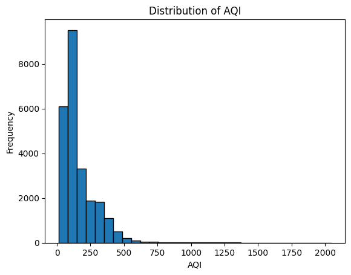

```python
import matplotlib.pyplot as plt

plt.hist(df['AQI'].dropna(), bins=30, edgecolor='black')
plt.title('Distribution of AQI')
plt.xlabel('AQI')
plt.ylabel('Frequency')
plt.show()
```

```python
from sklearn.ensemble import RandomForestRegressor
from sklearn.model_selection import train_test_split
from sklearn.metrics import mean_absolute_error, mean_squared_error, r2_score


features = ['PM2.5', 'PM10', 'NO', 'NO2', 'NOx', 'CO', 'SO2', 'O3', 'Benzene']
target = 'AQI'

train_data = df[df[target].notnull()]
predict_data = df[df[target].isnull()]

X = train_data[features]
y = train_data[target]

X_train, X_val, y_train, y_val = train_test_split(
    X, y, test_size=0.2, random_state=42)

model = RandomForestRegressor(random_state=42)
model.fit(X_train, y_train)


y_pred = model.predict(X_val)

mae = mean_absolute_error(y_val, y_pred)
mse = mean_squared_error(y_val, y_pred)
rmse = mse ** 0.5
r2 = r2_score(y_val, y_pred)

print(f"Validation MAE: {mae:.2f}")
print(f"Validation RMSE: {rmse:.2f}")
print(f"Validation R�: {r2:.3f}")

model.fit(X, y)

if not predict_data.empty:
    X_predict = predict_data[features]
    predicted_aqi = model.predict(X_predict)
    df.loc[df[target].isnull(), target] = predicted_aqi


missing_after_imputation = df[target].isnull().sum()
print(f"Remaining missing AQI values after imputation: {missing_after_imputation}")
```

```
Validation MAE: 21.60
Validation RMSE: 41.55
Validation R�: 0.906
Remaining missing AQI values after imputation: 0
```

```python
def get_aqi_bucket(aqi):
    if aqi <= 50:
        return "Good"
    elif aqi <= 100:
        return "Satisfactory"
    elif aqi <= 200:
        return "Moderate"
    elif aqi <= 300:
        return "Poor"
    elif aqi <= 400:
        return "Very Poor"
    else:
        return "Severe"

df['AQI_Bucket'] = df['AQI_Bucket'].fillna(df['AQI'].apply(get_aqi_bucket))
```

```python
cap = np.percentile(df['AQI'], 99.5)
df['AQI'] = np.where(df['AQI'] > cap, cap, df['AQI'])
```

```python
df['Date'] = pd.to_datetime(df['Date'], errors='coerce')
```

```python
df['Month'] = df['Date'].dt.month
df['Year'] = df['Date'].dt.year
```

```python
print(df['AQI'].value_counts().sort_index().head(20))
```

```
AQI
13.00     1
14.00     3
15.00     3
16.00     4
17.00     7
18.00     2
19.00    27
19.09     1
19.28     1
20.00    29
20.56     1
21.00     7
21.27     1
22.00     8
23.00     8
23.19     1
23.68     1
24.00     9
24.12     1
25.00     8
Name: count, dtype: int64
```

```python
df.reset_index(drop=True, inplace=True)
df
```

|  | City | Date | PM2.5 | PM10 | NO | NO2 | NOx | CO | SO2 | O3 | Benzene | AQI | AQI_Bucket | Month | Year |
| --- | --- | --- | --- | --- | --- | --- | --- | --- | --- | --- | --- | --- | --- | --- | --- |
| 0 | Ahmedabad | 2015-01-01 | 94.52 | 109.84 | 0.92 | 18.22 | 17.15 | 0.92 | 27.64 | 133.36 | 0.00 | 194.36 | Moderate | 1 | 2015 |
| 1 | Ahmedabad | 2015-01-02 | 94.52 | 109.84 | 0.97 | 15.69 | 16.46 | 0.97 | 24.55 | 34.06 | 3.68 | 199.16 | Moderate | 1 | 2015 |
| 2 | Ahmedabad | 2015-01-03 | 94.52 | 109.84 | 17.40 | 19.30 | 29.70 | 17.40 | 29.07 | 30.70 | 6.80 | 438.87 | Severe | 1 | 2015 |
| 3 | Ahmedabad | 2015-01-04 | 94.52 | 109.84 | 1.70 | 18.48 | 17.97 | 1.70 | 18.59 | 36.08 | 4.43 | 212.81 | Poor | 1 | 2015 |
| 4 | Ahmedabad | 2015-01-05 | 94.52 | 109.84 | 22.10 | 21.42 | 37.76 | 22.10 | 39.33 | 39.31 | 7.01 | 480.28 | Severe | 1 | 2015 |
| ... | ... | ... | ... | ... | ... | ... | ... | ... | ... | ... | ... | ... | ... | ... | ... |
| 29526 | Visakhapatnam | 2020-06-27 | 15.02 | 50.94 | 7.68 | 25.06 | 19.54 | 0.47 | 8.55 | 23.30 | 2.24 | 41.00 | Good | 6 | 2020 |
| 29527 | Visakhapatnam | 2020-06-28 | 24.38 | 74.09 | 3.42 | 26.06 | 16.53 | 0.52 | 12.72 | 30.14 | 0.74 | 70.00 | Satisfactory | 6 | 2020 |
| 29528 | Visakhapatnam | 2020-06-29 | 22.91 | 65.73 | 3.45 | 29.53 | 18.33 | 0.48 | 8.42 | 30.96 | 0.01 | 68.00 | Satisfactory | 6 | 2020 |
| 29529 | Visakhapatnam | 2020-06-30 | 16.64 | 49.97 | 4.05 | 29.26 | 18.80 | 0.52 | 9.84 | 28.30 | 0.00 | 54.00 | Satisfactory | 6 | 2020 |
| 29530 | Visakhapatnam | 2020-07-01 | 15.00 | 66.00 | 0.40 | 26.85 | 14.05 | 0.59 | 2.10 | 17.05 | 0.00 | 50.00 | Good | 7 | 2020 |

29531 rows × 15 columns

```python
df.to_csv("clean_air_quality.csv", index=False)
```

```python
df = pd.read_csv("clean_air_quality.csv")
df
```

|  | City | Date | PM2.5 | PM10 | NO | NO2 | NOx | CO | SO2 | O3 | Benzene | AQI | AQI_Bucket | Month | Year |
| --- | --- | --- | --- | --- | --- | --- | --- | --- | --- | --- | --- | --- | --- | --- | --- |
| 0 | Ahmedabad | 2015-01-01 | 94.52 | 109.84 | 0.92 | 18.22 | 17.15 | 0.92 | 27.64 | 133.36 | 0.00 | 194.36 | Moderate | 1 | 2015 |
| 1 | Ahmedabad | 2015-01-02 | 94.52 | 109.84 | 0.97 | 15.69 | 16.46 | 0.97 | 24.55 | 34.06 | 3.68 | 199.16 | Moderate | 1 | 2015 |
| 2 | Ahmedabad | 2015-01-03 | 94.52 | 109.84 | 17.40 | 19.30 | 29.70 | 17.40 | 29.07 | 30.70 | 6.80 | 438.87 | Severe | 1 | 2015 |
| 3 | Ahmedabad | 2015-01-04 | 94.52 | 109.84 | 1.70 | 18.48 | 17.97 | 1.70 | 18.59 | 36.08 | 4.43 | 212.81 | Poor | 1 | 2015 |
| 4 | Ahmedabad | 2015-01-05 | 94.52 | 109.84 | 22.10 | 21.42 | 37.76 | 22.10 | 39.33 | 39.31 | 7.01 | 480.28 | Severe | 1 | 2015 |
| ... | ... | ... | ... | ... | ... | ... | ... | ... | ... | ... | ... | ... | ... | ... | ... |
| 29526 | Visakhapatnam | 2020-06-27 | 15.02 | 50.94 | 7.68 | 25.06 | 19.54 | 0.47 | 8.55 | 23.30 | 2.24 | 41.00 | Good | 6 | 2020 |
| 29527 | Visakhapatnam | 2020-06-28 | 24.38 | 74.09 | 3.42 | 26.06 | 16.53 | 0.52 | 12.72 | 30.14 | 0.74 | 70.00 | Satisfactory | 6 | 2020 |
| 29528 | Visakhapatnam | 2020-06-29 | 22.91 | 65.73 | 3.45 | 29.53 | 18.33 | 0.48 | 8.42 | 30.96 | 0.01 | 68.00 | Satisfactory | 6 | 2020 |
| 29529 | Visakhapatnam | 2020-06-30 | 16.64 | 49.97 | 4.05 | 29.26 | 18.80 | 0.52 | 9.84 | 28.30 | 0.00 | 54.00 | Satisfactory | 6 | 2020 |
| 29530 | Visakhapatnam | 2020-07-01 | 15.00 | 66.00 | 0.40 | 26.85 | 14.05 | 0.59 | 2.10 | 17.05 | 0.00 | 50.00 | Good | 7 | 2020 |

29531 rows × 15 columns

```python
df.count()
```

```
City          29531
Date          29531
PM2.5         29531
PM10          29531
NO            29531
NO2           29531
NOx           29531
CO            29531
SO2           29531
O3            29531
Benzene       29531
AQI           29531
AQI_Bucket    29531
Month         29531
Year          29531
dtype: int64
```

```python
df['AQI_Bucket'].unique()
```

```
array(['Moderate', 'Severe', 'Poor', 'Very Poor', 'Satisfactory', 'Good'],
      dtype=object)
```

```python
df['City'].unique()
```

```
array(['Ahmedabad', 'Aizawl', 'Amaravati', 'Amritsar', 'Bengaluru',
       'Bhopal', 'Brajrajnagar', 'Chandigarh', 'Chennai', 'Coimbatore',
       'Delhi', 'Ernakulam', 'Gurugram', 'Guwahati', 'Hyderabad',
       'Jaipur', 'Jorapokhar', 'Kochi', 'Kolkata', 'Lucknow', 'Mumbai',
       'Patna', 'Shillong', 'Talcher', 'Thiruvananthapuram',
       'Visakhapatnam'], dtype=object)
```

```python
len(df['City'].unique())
```

```
26
```

```python
df.max(numeric_only=True)
```

```
PM2.5       949.9900
PM10       1000.0000
NO          390.6800
NO2         362.2100
NOx         467.6300
CO          175.8100
SO2         193.8600
O3          257.7300
Benzene     455.0300
AQI        1147.4285
Month        12.0000
Year       2020.0000
dtype: float64
```

```python
len(df[df['AQI']>900])
```

```
331
```

```python
df.AQI.mean()
```

```
171.39954617181942
```

```python
df.AQI.median()
```

```
118.0
```

```python
# if the mean is greater than the median it means the data is positively skewed
```

```python
df.City.mode()
```

```
0    Ahmedabad
1    Bengaluru
2      Chennai
3        Delhi
4      Lucknow
5       Mumbai
Name: City, dtype: object
```

```python
df.AQI.value_counts()
```

```
AQI
100.00    224
102.00    223
106.00    208
70.00     208
78.00     200
         ...
63.97       1
66.99       1
80.91       1
112.13      1
38.72       1
Name: count, Length: 4427, dtype: int64
```

```python
df.AQI.max()
```

```
1147.4285
```

```python
df.AQI
```

```
0        194.36
1        199.16
2        438.87
3        212.81
4        480.28
          ...
29526     41.00
29527     70.00
29528     68.00
29529     54.00
29530     50.00
Name: AQI, Length: 29531, dtype: float64
```

```python
df.City.value_counts()
```

```
City
Ahmedabad             2009
Delhi                 2009
Mumbai                2009
Bengaluru             2009
Lucknow               2009
Chennai               2009
Hyderabad             2006
Patna                 1858
Gurugram              1679
Visakhapatnam         1462
Amritsar              1221
Jorapokhar            1169
Jaipur                1114
Thiruvananthapuram    1112
Amaravati              951
Brajrajnagar           938
Talcher                925
Kolkata                814
Guwahati               502
Coimbatore             386
Shillong               310
Chandigarh             304
Bhopal                 289
Ernakulam              162
Kochi                  162
Aizawl                 113
Name: count, dtype: int64
```

```python
df.AQI.var()
```

```
23625.8912603092
```

```python
df.AQI.std()
```

```
153.70716073205307
```

```python
df[df.City=='Delhi'].AQI.mean()
```

```
258.62410154305627
```

```python
df[df.City=='Bengaluru'].AQI.mean()
```

```
97.37399203583873
```

```python
df[df.City=='Ahmedabad'].AQI.mean()
```

```
490.5250861124938
```

```python
for pos in df.City.unique():
    print(pos, '\t:', df[df.City == pos].AQI.mean())
```

```
Ahmedabad 	: 490.5250861124938
Aizawl 	: 34.916017699115045
Amaravati 	: 93.28805467928497
Amritsar 	: 120.38733824733825
Bengaluru 	: 97.37399203583873
Bhopal 	: 131.09024221453288
Brajrajnagar 	: 156.86684434968018
Chandigarh 	: 96.72523026315788
Chennai 	: 118.93825783972125
Coimbatore 	: 74.59862694300519
Delhi 	: 258.62410154305627
Ernakulam 	: 93.28271604938273
Gurugram 	: 222.50042287075638
Guwahati 	: 141.6328685258964
Hyderabad 	: 107.95223828514457
Jaipur 	: 132.93824955116696
Jorapokhar 	: 165.12124037639006
Kochi 	: 104.77685185185184
Kolkata 	: 135.28874692874695
Lucknow 	: 227.62401194624192
Mumbai 	: 101.8205525136884
Patna 	: 224.15724973089343
Shillong 	: 53.59464516129031
Talcher 	: 168.9058054054054
Thiruvananthapuram 	: 74.64118705035972
Visakhapatnam 	: 109.68168262653899
```

```python
df.groupby('City').AQI.mean()
```

```
City
Ahmedabad             490.525086
Aizawl                 34.916018
Amaravati              93.288055
Amritsar              120.387338
Bengaluru              97.373992
Bhopal                131.090242
Brajrajnagar          156.866844
Chandigarh             96.725230
Chennai               118.938258
Coimbatore             74.598627
Delhi                 258.624102
Ernakulam              93.282716
Gurugram              222.500423
Guwahati              141.632869
Hyderabad             107.952238
Jaipur                132.938250
Jorapokhar            165.121240
Kochi                 104.776852
Kolkata               135.288747
Lucknow               227.624012
Mumbai                101.820553
Patna                 224.157250
Shillong               53.594645
Talcher               168.905805
Thiruvananthapuram     74.641187
Visakhapatnam         109.681683
Name: AQI, dtype: float64
```

```python
top_5_cities_by_aqi = df.groupby('City')['AQI'].mean().sort_values(ascending=False).head(5)
top_5_cities_by_aqi
```

```
City
Ahmedabad    490.525086
Delhi        258.624102
Lucknow      227.624012
Patna        224.157250
Gurugram     222.500423
Name: AQI, dtype: float64
```

```python
highest_aqi_row = df.loc[df['AQI'].idxmax()]
highest_aqi_row
```

```
City           Ahmedabad
Date          2015-01-07
PM2.5              94.52
PM10              109.84
NO                112.16
NO2                40.62
NOx               130.77
CO                112.16
SO2                32.28
O3                 33.47
Benzene              0.0
AQI            1147.4285
AQI_Bucket        Severe
Month                  1
Year                2015
Name: 6, dtype: object
```

```python
def get_season(month):
    if month in [11,12, 1, 2]:
        return "Winter"
    elif month in [3, 4, 5]:
        return "Spring"
    elif month in [6, 7, 8]:
        return "Summer"
    else:
        return "Autumn"

df['Season'] = df['Month'].apply(get_season)

winter_data = df[df['Season'] == 'Winter']
# winter_data = df[(df['Season'] == 'Winter') & (df['Year'] == 2015)]

top_5_winter_aqi = winter_data.groupby('City')['AQI'].mean().sort_values(ascending=False).head(5)

print("Top 5 cities with the highest AQI in the winter season:")
print(top_5_winter_aqi)
```

```
Top 5 cities with the highest AQI in the winter season:
City
Ahmedabad    542.612212
Delhi        356.524962
Patna        353.227824
Lucknow      345.569395
Gurugram     283.058299
Name: AQI, dtype: float64
```

```python
import pandas as pd

pollutant_columns = ['PM2.5', 'PM10', 'NO', 'NO2', 'NOx', 'CO', 'SO2', 'O3', 'Benzene']


correlations = df[pollutant_columns].corrwith(df['AQI'])

most_harmful_pollutant = correlations.idxmax()
highest_correlation = correlations.max()

print("Correlation of each pollutant with AQI:")
print(correlations)

print(f"The most influential pollutant (highest correlation with AQI) is: {most_harmful_pollutant}")
print(f"Correlation value: {highest_correlation:.4f}")
```

```
Correlation of each pollutant with AQI:
PM2.5      0.608441
PM10       0.391828
NO         0.352135
NO2        0.425867
NOx        0.328229
CO         0.621188
SO2        0.301014
O3         0.160772
Benzene    0.035782
dtype: float64
The most influential pollutant (highest correlation with AQI) is: CO
Correlation value: 0.6212
```

```python
    pollutant_columns = ['PM2.5', 'PM10', 'NO', 'NO2', 'NOx', 'CO', 'SO2', 'O3', 'Benzene']

    correlations_by_city = df.groupby('City').apply(
        lambda x: x[pollutant_columns].corrwith(x['AQI'])
    )

    print(correlations_by_city)
```

```
                       PM2.5      PM10        NO       NO2       NOx  \
City
Ahmedabad           0.504624  0.112613  0.596538  0.252284  0.427714
Aizawl              0.949149  0.940350 -0.807101  0.258426 -0.794766
Amaravati           0.913289  0.889783  0.229807  0.727704  0.689484
Amritsar            0.596547  0.853558  0.214892  0.224395  0.367747
Bengaluru           0.359302  0.445202  0.106493  0.157693  0.127588
Bhopal              0.900256  0.852786  0.431799  0.699609  0.652793
Brajrajnagar        0.878852  0.818862  0.124726  0.522443  0.288349
Chandigarh          0.906658  0.871786  0.421150  0.145713  0.388466
Chennai             0.756808  0.131093  0.173526  0.215179 -0.017671
Coimbatore          0.554672  0.581815 -0.328928  0.001102  0.156827
Delhi               0.882445  0.869224  0.639901  0.657338  0.559881
Ernakulam           0.334893  0.324534  0.499878  0.137893  0.500326
Gurugram            0.841552  0.480968  0.134233  0.120730  0.173025
Guwahati            0.707446  0.841216  0.644556  0.418257  0.630770
Hyderabad           0.797320  0.498995  0.155333  0.109941  0.191869
Jaipur              0.853433  0.841245  0.441463  0.444986  0.448013
Jorapokhar          0.486686  0.811123 -0.116972 -0.070062 -0.040733
Kochi               0.605240  0.613377  0.533421  0.379332  0.638952
Kolkata             0.967625  0.972397  0.812100  0.865531  0.898373
Lucknow             0.901311 -0.212781  0.409659  0.419917  0.298303
Mumbai              0.831316  0.766742  0.216845  0.598831  0.602708
Patna               0.924502  0.009932  0.388403  0.113295  0.371550
Shillong            0.899166  0.919744  0.135103  0.159304  0.202774
Talcher             0.803484  0.906653 -0.067652  0.118630  0.155633
Thiruvananthapuram  0.813567  0.768276  0.019675  0.319227  0.146596
Visakhapatnam       0.900350  0.874413  0.368167  0.587966  0.561283

                          CO       SO2        O3   Benzene
City
Ahmedabad           0.599783  0.405823 -0.010818  0.032327
Aizawl              0.748488 -0.196231  0.558415 -0.229684
Amaravati           0.248912  0.226266  0.461535  0.050778
Amritsar            0.430788 -0.001741  0.002324  0.174617
Bengaluru           0.494482  0.244908  0.226347  0.329750
Bhopal              0.675888  0.281491  0.191622  0.447428
Brajrajnagar        0.428136  0.294001 -0.061500 -0.015467
Chandigarh          0.626003 -0.119431 -0.213626  0.345635
Chennai             0.399916  0.073777  0.209809  0.038982
Coimbatore          0.274792  0.198560  0.299405  0.043785
Delhi               0.283253  0.429320  0.368119  0.672827
Ernakulam           0.464439 -0.092950  0.034373  0.328603
Gurugram            0.266613  0.084806 -0.067752 -0.009215
Guwahati            0.691123  0.097894 -0.041474 -0.014746
Hyderabad           0.369919  0.221292  0.292088  0.174407
Jaipur              0.166834  0.105548  0.310911  0.409005
Jorapokhar         -0.228213  0.465209  0.158385 -0.040733
Kochi               0.097694  0.129295  0.445955 -0.495030
Kolkata             0.649075  0.439191  0.280473  0.418950
Lucknow             0.354040  0.372263  0.181301  0.119592
Mumbai              0.403276  0.013818  0.407394  0.374316
Patna               0.624821  0.018033 -0.045366  0.005476
Shillong            0.286457  0.073657  0.287544  0.060386
Talcher             0.250593  0.066061 -0.018647 -0.017525
Thiruvananthapuram  0.562286  0.459387  0.573115 -0.075038
Visakhapatnam       0.582964  0.207233  0.564122  0.407969
```

### Other Key Pollutants: While PM2.5 and PM10 are dominant, other pollutants are the most influential in certain cities:

### In Delhi, Benzene also has a very high correlation (0.6728), indicating it is also a significant factor in air quality.

### In Aizawl, CO has a high correlation (0.748), while NO has a strong negative correlation (-0.807), suggesting that as NO levels rise, the AQI tends to improve in this specific dataset. This could be due to complex atmospheric reactions or data anomalies.

### Variety of Influencers: The data shows that there isn't a single "most harmful" pollutant across all cities. The factors that most affect air quality can vary significantly by location. For instance, in Kolkata, PM2.5 and PM10 have the highest correlations, whereas in Delhi, PM2.5, PM10, and Benzene all appear to be very influential.

```python
import pandas as pd

def get_season(month):
    if month in [12, 1, 2]:
        return "Winter"
    elif month in [3, 4, 5]:
        return "Spring"
    elif month in [6, 7, 8]:
        return "Summer"
    else:
        return "Autumn"


df['Season'] = df['Month'].apply(get_season)

winter_df = df[df['Season'] == 'Winter']



pollutant_columns = ['PM2.5', 'PM10', 'NO', 'NO2', 'NOx', 'CO', 'SO2', 'O3', 'Benzene']

winter_correlations_by_city = winter_df.groupby('City').apply(
    lambda x: x[pollutant_columns].corrwith(x['AQI'])
)

print("Correlation of each pollutant with AQI in the Winter season, by city:")
print(winter_correlations_by_city)
```

```
Correlation of each pollutant with AQI in the Winter season, by city:
                       PM2.5      PM10        NO       NO2       NOx  \
City
Ahmedabad           0.525967  0.201437  0.858543  0.319283  0.488557
Amaravati           0.939681  0.913093  0.330659  0.714443  0.683754
Amritsar            0.893734  0.851525  0.141801  0.209338  0.274040
Bengaluru           0.393463  0.385494  0.163527  0.036446  0.077794
Bhopal              0.842745  0.718756  0.045736  0.422504  0.308697
Brajrajnagar        0.901328  0.787762  0.015926  0.295632  0.286814
Chandigarh          0.837611  0.739264  0.540419  0.246896  0.569882
Chennai             0.841800  0.206426  0.144571  0.046823 -0.097089
Coimbatore          0.593899  0.515513 -0.304929  0.308302  0.350330
Delhi               0.906367  0.810603  0.540958  0.566416  0.436838
Ernakulam           0.520193  0.470841  0.799961  0.058777  0.837469
Gurugram            0.909214  0.590710  0.178271  0.045330  0.177477
Guwahati            0.828352  0.811821  0.624508  0.249391  0.611339
Hyderabad           0.822227  0.558122  0.088506  0.146578  0.018050
Jaipur              0.835378  0.776239  0.467161  0.242455  0.304260
Jorapokhar          0.697500  0.888598 -0.174599 -0.275179  0.029007
Kochi               0.712853  0.518361  0.359391  0.317227  0.458621
Kolkata             0.951624  0.944751  0.729872  0.788495  0.812787
Lucknow             0.878663 -0.521675  0.163575 -0.013755 -0.110809
Mumbai              0.861985  0.837451 -0.053749  0.666357  0.459560
Patna               0.908356 -0.265333  0.279350 -0.125357  0.042451
Shillong            0.885932  0.897133  0.543328  0.297267  0.518266
Talcher             0.688322  0.857218  0.271219  0.293403  0.279951
Thiruvananthapuram  0.801286  0.774673 -0.317645 -0.219784 -0.282113
Visakhapatnam       0.914271  0.867231  0.411328  0.575427  0.546435

                          CO       SO2        O3   Benzene
City
Ahmedabad           0.858543  0.440830 -0.175320 -0.095341
Amaravati           0.094268  0.139263  0.249160 -0.173991
Amritsar            0.549810 -0.008507  0.116757  0.327114
Bengaluru           0.737551  0.386514  0.060171  0.233189
Bhopal              0.595435 -0.039717 -0.093552  0.477880
Brajrajnagar        0.548314  0.323838 -0.313461 -0.203155
Chandigarh          0.624244  0.180108 -0.097058  0.313650
Chennai             0.352904 -0.077052  0.195546  0.376578
Coimbatore          0.086000  0.250624  0.708902 -0.120543
Delhi               0.057468  0.270944  0.315689  0.621071
Ernakulam           0.072890 -0.136904  0.504376 -0.005778
Gurugram            0.390076  0.095915 -0.120774  0.434664
Guwahati            0.825100 -0.152403 -0.313961  0.114474
Hyderabad           0.272203  0.218317  0.314550  0.204874
Jaipur             -0.060511  0.079597  0.113704  0.125137
Jorapokhar         -0.336678  0.400299 -0.093793  0.029007
Kochi               0.308576 -0.217134  0.281731 -0.216864
Kolkata             0.570234  0.451360 -0.134463  0.045088
Lucknow             0.464567  0.380111 -0.058952  0.091221
Mumbai              0.600313 -0.281368  0.396733  0.730156
Patna               0.686589  0.126970 -0.003944  0.084293
Shillong            0.645979  0.724462  0.560761 -0.016293
Talcher             0.212319  0.386638  0.279585  0.057260
Thiruvananthapuram  0.310182  0.279072  0.450007 -0.319593
Visakhapatnam       0.387140  0.397782  0.289452  0.167028
```

```python
df['AQI'].skew()
```

```
3.1501102730986004
```

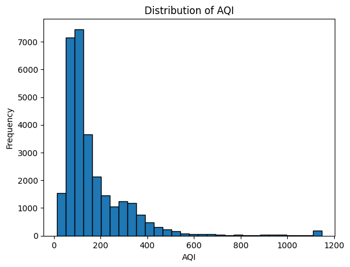

```python
import matplotlib.pyplot as plt
plt.hist(df['AQI'].dropna(), bins=30, edgecolor='black')
plt.title('Distribution of AQI')
plt.xlabel('AQI')
plt.ylabel('Frequency')
plt.show()
```

```python
df['AQI'].kurt()
```

```
13.960628101897854
```

```python
mad = (df['AQI'] - df['AQI'].mean()).abs().mean()
print("MAD (Mean Absolute Deviation):", mad)
```

```
MAD (Mean Absolute Deviation): 102.08950523351837
```

```python
cov_matrix = df[['AQI', 'PM2.5']].cov()
print("Covariance matrix:\n", cov_matrix)

cov_value = df['AQI'].cov(df['PM2.5'])
print("Covariance between AQI and PM2.5:", cov_value)
```

```
Covariance matrix:
                 AQI        PM2.5
AQI    23625.891260  6188.713156
PM2.5   6188.713156  4379.001590
Covariance between AQI and PM2.5: 6188.713155712168
```

# Sql operations

### Use the database

# Use the `cityair` database

USE cityair;

### Show available tables

# View all tables in the selected database

SHOW TABLES;

### View all data in `city_clean`

# Select everything from the city_clean table

SELECT * FROM city_clean;

### Get city with highest average AQI in 2019

# Calculate average AQI for each city in 2019 and get the one with highest value

SELECT City, AVG(AQI) AS avg_aqi FROM city_clean WHERE Year = 2019 GROUP BY City ORDER BY avg_aqi DESC LIMIT 1;

### Get all 'Severe' AQI days in Delhi

# Filter records where AQI_Bucket is 'Severe' for city 'Delhi'

SELECT Date, AQI FROM city_clean WHERE City = 'Delhi' AND AQI_Bucket = 'Severe';

### Get average PM2.5 by month for Mumbai and Chennai

# Monthly average PM2.5 levels in Mumbai and Chennai

SELECT City, Month, AVG(`PM2.5`) AS avg_pm25 FROM city_clean WHERE City IN ('Mumbai', 'Chennai') GROUP BY City, Month ORDER BY City, Month;

### Get national average CO level

# Find the overall national average for CO

SELECT AVG(CO) AS national_avg_CO FROM city_clean;

### Find cities with CO levels above national average

# List cities where average CO is greater than national average

SELECT City, AVG(CO) AS avg_city_CO FROM city_clean GROUP BY City HAVING AVG(CO) > (SELECT AVG(CO) FROM city_clean) ORDER BY avg_city_CO DESC;

### Top 5 cities with highest number of 'Good' AQI days

# Count how many days had 'Good' AQI per city, sort and take top 5

SELECT City, COUNT(*) AS good_days FROM city_clean WHERE AQI_Bucket = 'Good' GROUP BY City ORDER BY good_days DESC LIMIT 5;

### Group by city and compute correlation

```python
cities = df['City'].unique()
pollutants = ['PM2.5', 'PM10', 'NO2', 'NO', 'SO2', 'CO', 'O3', 'NH3', 'NOx']

for city in cities:
    city_df = df[df['City'] == city]
    corr = city_df[pollutants + ['AQI']].corr()['AQI'].sort_values(ascending=False)
    print(f"\n* Top pollutants in {city}:")
    print(corr[1:4])
```

[output not shown]

[output cut: 100 more lines]

[output not shown]

# Data Visulalisation

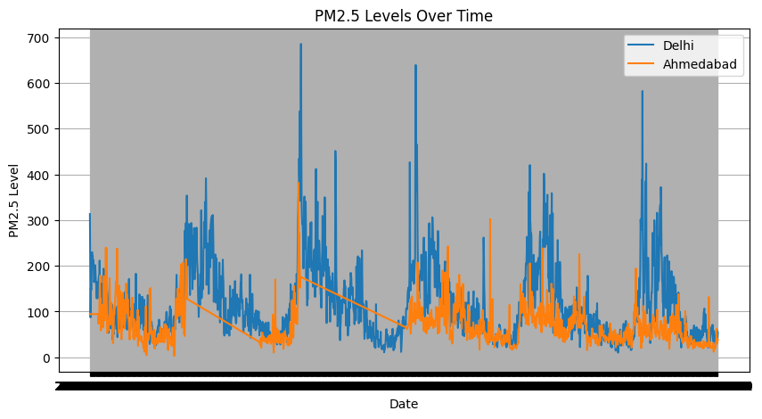

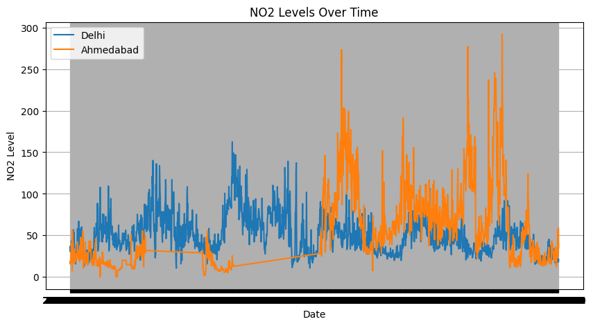

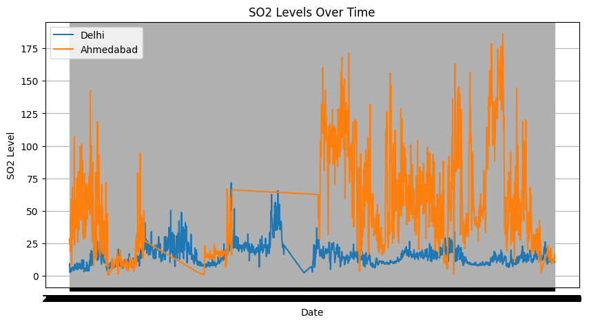

```python
import pandas as pd
import matplotlib.pyplot as plt
import seaborn as sns

df=pd.read_csv("clean_air_quality.csv")


df_filtered = df[df['City'].isin(['Delhi', 'Ahmedabad'])]


pollutants = ['PM2.5', 'NO2', 'SO2']

for pollutant in pollutants:
    plt.figure(figsize=(10, 5))

    for city in ['Delhi', 'Ahmedabad']:
        city_data = df_filtered[df_filtered['City'] == city]

        daily_avg = city_data.groupby('Date')[pollutant].mean()
        plt.plot(daily_avg.index, daily_avg.values, label=city)

    plt.title(f"{pollutant} Levels Over Time")
    plt.xlabel("Date")
    plt.ylabel(f"{pollutant} Level")
    plt.legend()
    plt.grid(True)
    plt.show()
```

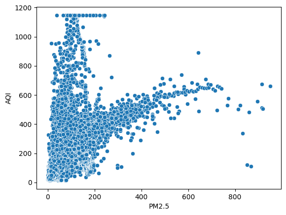

```python
sns.scatterplot(x='PM2.5', y='AQI', data=df)
plt.show()
```

### Conclusion Summary: Ahmedabad Air Quality

### PM2.5 is lower in Ahmedabad

### → Less fine dust, possibly due to fewer vehicles or less construction

### NO2 and SO2 levels are higher

### → Likely due to more industrial activity or fuel burning

### AQI is still high despite low PM2.5

### → AQI includes multiple pollutants, not just dust

### Final note:

### Ahmedabad has less dust pollution but more gas-based pollution,

### which leads to poor overall air quality.

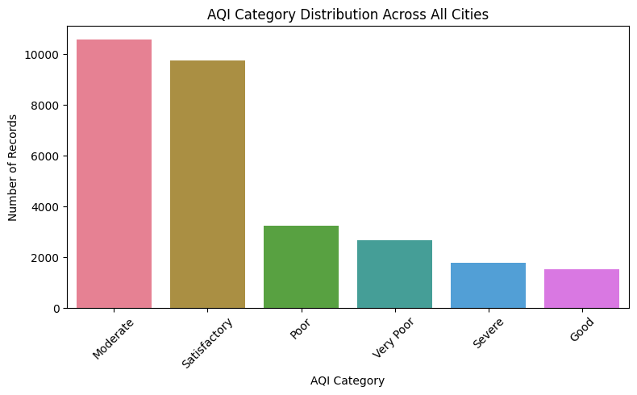

```python
import matplotlib.pyplot as plt
import seaborn as sns


aqi_counts = df['AQI_Bucket'].value_counts()


plt.figure(figsize=(8, 5))
sns.barplot(x=aqi_counts.index, y=aqi_counts.values, palette="husl")
plt.title("AQI Category Distribution Across All Cities")
plt.xlabel("AQI Category")
plt.ylabel("Number of Records")
plt.xticks(rotation=45)
plt.tight_layout()
plt.show()
```

### Interpretation: "Moderate" and "Satisfactory" AQI are higher

### What it means:

- Most of the air quality records in your dataset fall in the middle two categories of the AQI scale.
- These categories indicate acceptable air quality — not very clean, but not hazardous either.

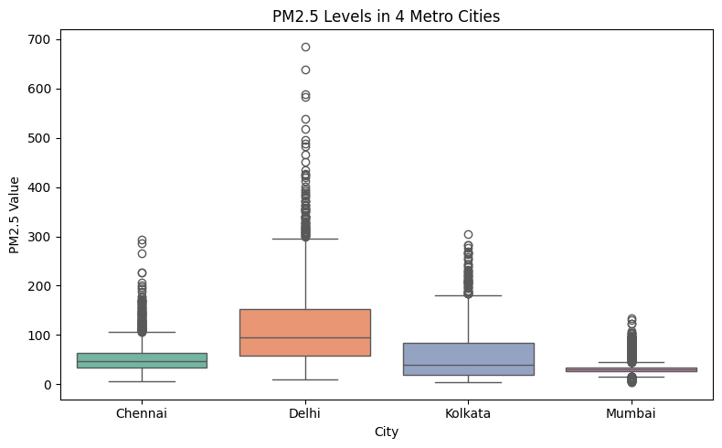

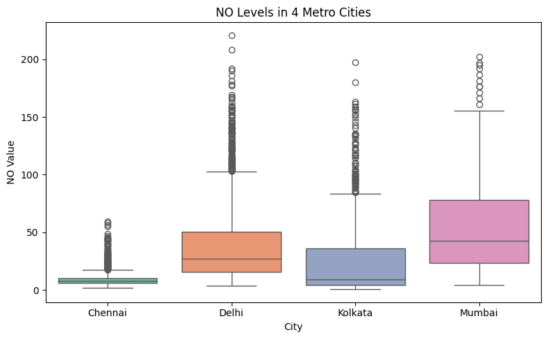

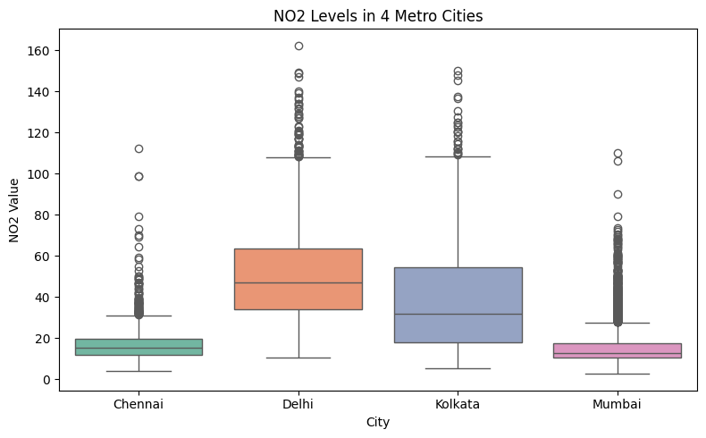

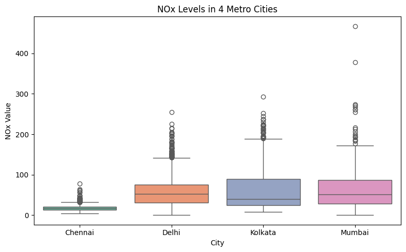

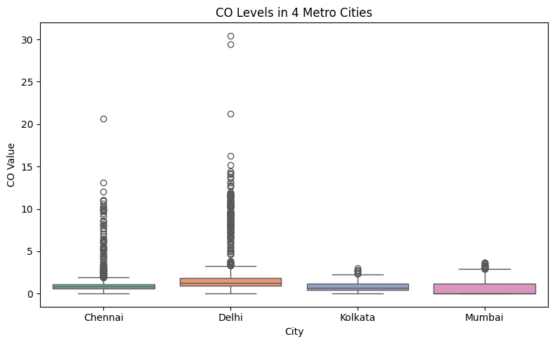

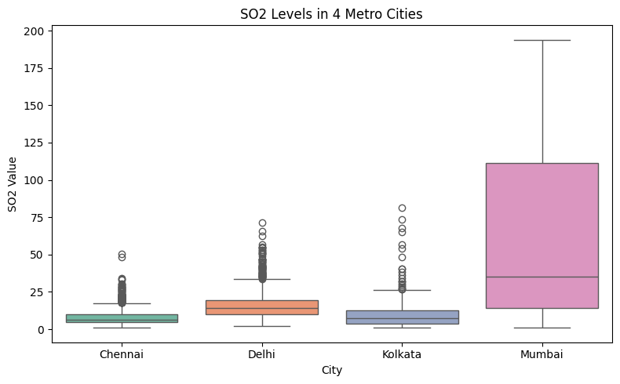

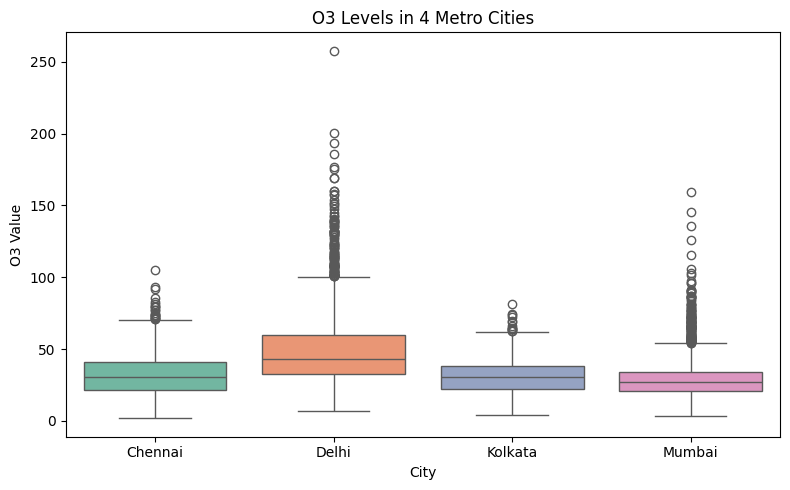

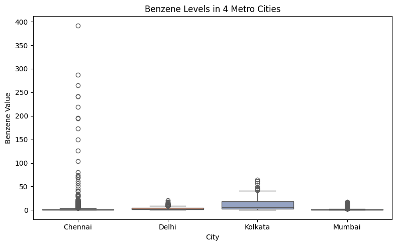

```python
import seaborn as sns
import matplotlib.pyplot as plt

metro_cities = ['Delhi', 'Mumbai', 'Chennai', 'Kolkata']
df_metro = df[(df['City'] == 'Delhi') |
              (df['City'] == 'Mumbai') |
              (df['City'] == 'Chennai') |
              (df['City'] == 'Kolkata')]


pollutants = ['PM2.5', 'NO', 'NO2', 'NOx',
    'CO', 'SO2', 'O3', 'Benzene']


for pollutant in pollutants:
    plt.figure(figsize=(8, 5))
    sns.boxplot(x='City', y=pollutant, data=df_metro, palette='Set2')
    plt.title(f'{pollutant} Levels in 4 Metro Cities')
    plt.xlabel('City')
    plt.ylabel(f'{pollutant} Value')
    plt.tight_layout()
    plt.show()
```

### Delhi:

### CO → From high traffic, diesel engines, and winter air trapping

### Benzene → Emitted by petrol vehicles and fuel evaporation

### Chennai:

### Benzene → From petrochemical industries (e.g., Manali area)

### CO → From industrial boilers, ports, and petrol vehicles

```python
pollutants = ['PM2.5', 'NO', 'NO2', 'NOx',
    'CO', 'SO2', 'O3', 'Benzene']
df_corr = df[pollutants]
```

```python
corr_matrix = df_corr.corr()
```

[figure not shown]

```python
plt.figure(figsize=(8, 4))
sns.heatmap(corr_matrix, annot=True, cmap='coolwarm', fmt='.2f')
plt.title("Correlation Between Pollutants and AQI")
plt.tight_layout()
plt.show()
```

### Key Insights in Simple Terms

### NO and NOx are closely related (correlation ~0.63)

### → When NO increases, NOx also rises — likely from same sources

### PM2.5 has weak links with other pollutants

### → It behaves more independently, may come from different sources

### Practical Meaning:

### → Some pollutants come from common sources (like traffic/industry)

### → Others (like Benzene, O3) may have separate or reactive origins

### Helps decide which pollutants to monitor together

### → Useful for better pollution control strategies

### Impact of NO and NOx

### 1. Air Pollution & Health

### → Affects lungs, especially in kids, elderly, asthma patients

### 2. Forms ground-level O3 and PM2.5

### → Both are harmful and regulated pollutants

### 3. Contributes to smog formation

### 4. Causes environmental and climate damage

```python
top_city = df['City'].value_counts().head(5)
print("Top 5 cities with highest number of AQI records:\n", top_city)
```

```
Top 5 cities with highest number of AQI records:
 City
Ahmedabad    2009
Delhi        2009
Mumbai       2009
Bengaluru    2009
Lucknow      2009
Name: count, dtype: int64
```

```python
monthly_avg = df.groupby(['City', 'Year', 'Month'])['AQI'].mean().reset_index()
```

```python
len(df['City'].unique())
```

```
26
```

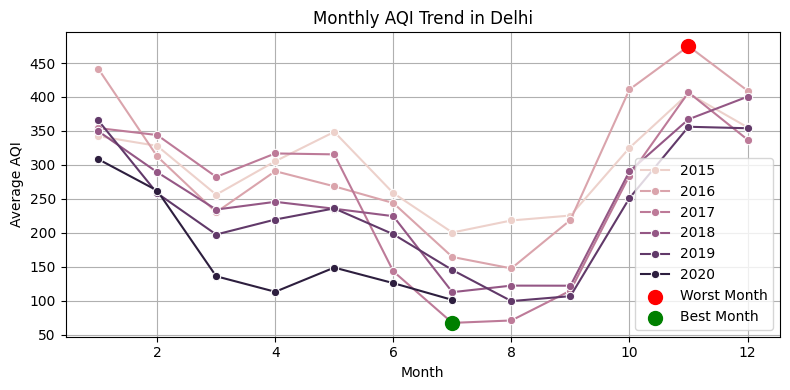

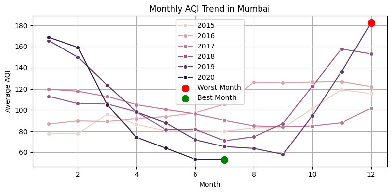

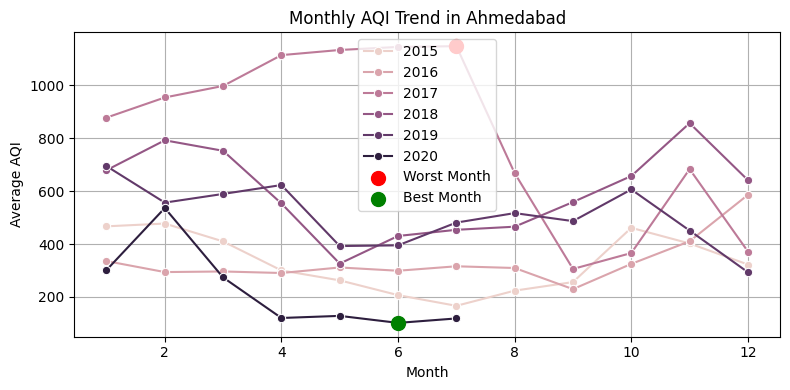

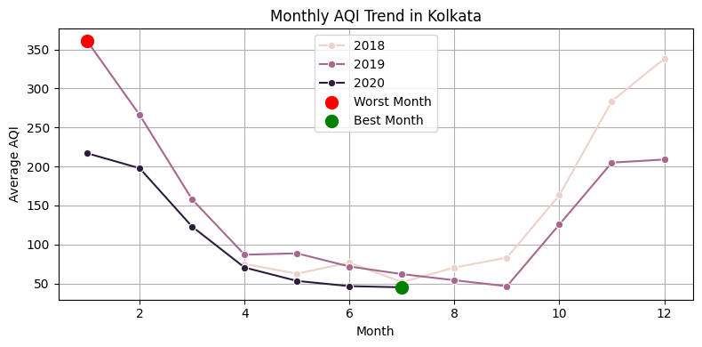

```python
cities = ['Delhi', 'Mumbai', 'Ahmedabad', 'Kolkata']


for city in cities:
    city_data = monthly_avg[monthly_avg['City'] == city]

    plt.figure(figsize=(8, 4))
    sns.lineplot(x='Month', y='AQI', hue='Year', data=city_data, marker='o')

    # Highlight worst and best months
    worst = city_data.loc[city_data['AQI'].idxmax()]
    best = city_data.loc[city_data['AQI'].idxmin()]

    plt.scatter(worst['Month'], worst['AQI'], color='red', label='Worst Month', s=100, zorder=5)
    plt.scatter(best['Month'], best['AQI'], color='green', label='Best Month', s=100, zorder=5)

    plt.title(f"Monthly AQI Trend in {city}")
    plt.xlabel("Month")
    plt.ylabel("Average AQI")
    plt.legend()
    plt.grid(True)
    plt.tight_layout()
    plt.show()
```

### Why are AQI levels worse in winter?

### Low wind and temperature inversion trap pollutants near the ground

### → Pollutants accumulate instead of dispersing

### Crop burning in Oct–Nov (Punjab, Haryana)

### → Smoke drifts into Delhi, raising PM2.5 and AQI

### Firecrackers during Diwali

### → Add PM2.5 and PM10 particles, spiking pollution

### Increased vehicle and heating use in winter

### → More emissions worsen air quality

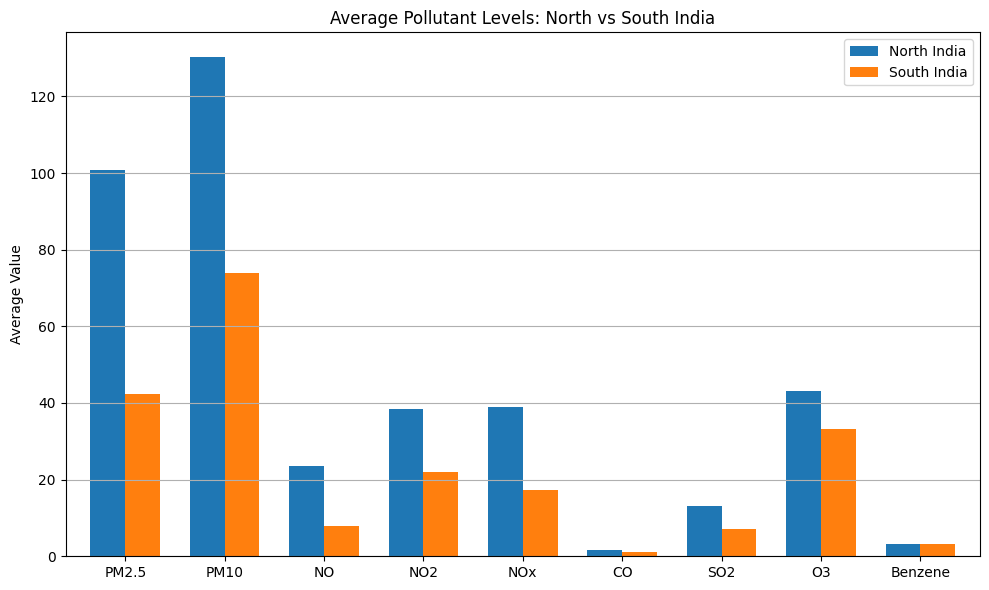

```python
north_cities = ['Delhi', 'Lucknow', 'Jaipur', 'Chandigarh']
south_cities = ['Chennai', 'Bengaluru', 'Hyderabad', 'Thiruvananthapuram']


north_data = df[df['City'].isin(north_cities)]
south_data = df[df['City'].isin(south_cities)]


pollutants = ['PM2.5','PM10', 'NO', 'NO2', 'NOx',
    'CO', 'SO2', 'O3', 'Benzene']
north_avg = north_data[pollutants].mean()
south_avg = south_data[pollutants].mean()


comparison = pd.DataFrame({
    'North India': north_avg,
    'South India': south_avg
})

comparison.plot(kind='bar', figsize=(10, 6), width=0.7)
plt.title('Average Pollutant Levels: North vs South India')
plt.ylabel('Average Value')
plt.xticks(rotation=0)
plt.grid(axis='y')
plt.tight_layout()
plt.show()
```

```python
severe_days = df[df['AQI_Bucket'] == 'Severe']
```

```python
pollutants = ['PM2.5', 'NO', 'NO2', 'NOx',
    'CO', 'SO2', 'O3', 'Benzene']
severe_avg = severe_days[pollutants].mean().sort_values(ascending=False)
```

```python
top_3_pollutants = severe_avg.head(3)
print(top_3_pollutants)
```

```
PM2.5    191.044321
NOx       59.734911
NO2       56.877041
dtype: float64
```

### 2. NOx / NO2 → From vehicles, power plants, industries

### → Form smog, cause breathing issues

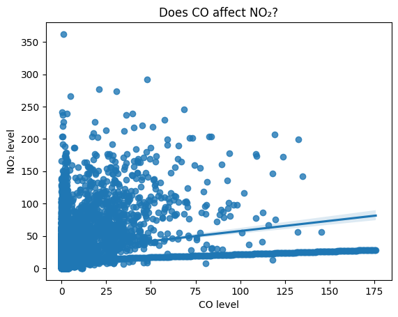

```python
sns.regplot(x='CO', y='NO2', data=df)
plt.title("Does CO affect NO₂?")
plt.xlabel("CO level")
plt.ylabel("NO₂ level")
plt.show()
```

### Key Observations (CO vs NO₂)

### Weak positive trend → Slight NO₂ rise as CO increases, but scattered points show weak relation

### High density at low CO (0–25) → NO₂ still varies a lot, even when CO is low

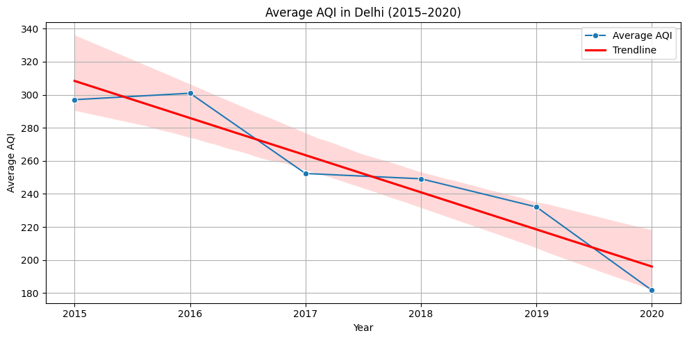

```python
delhi_data = df[df['City'] == 'Delhi'].copy()


delhi_data['Date'] = pd.to_datetime(delhi_data['Date'])

delhi_data['Year'] = delhi_data['Date'].dt.year

delhi_data = df[df['City'] == 'Delhi'].copy()


delhi_data['Date'] = pd.to_datetime(delhi_data['Date'])

# Step 3: Extract 'Year'
delhi_data['Year'] = delhi_data['Date'].dt.year

# Step 4: Group by Year and calculate average AQI
yearly_avg = delhi_data.groupby('Year')['AQI'].mean().reset_index()


plt.figure(figsize=(10,5))
sns.lineplot(data=yearly_avg, x='Year', y='AQI', marker='o', label='Average AQI')
sns.regplot(data=yearly_avg, x='Year', y='AQI', scatter=False, label='Trendline', color="red")

plt.title('Average AQI in Delhi (2015–2020)')
plt.xlabel('Year')
plt.ylabel('Average AQI')
plt.legend()
plt.grid(True)
plt.tight_layout()
plt.show()
```

### Timeline: Stubble Burning Actions in India

### 2015 → NGT banned stubble burning in 5 states; enforcement was weak

### 2017 → EPCA pushed for stricter action; satellite data showed high burn events

### 2018–19 → Govt gave subsidies for machines (e.g., Happy Seeder); crop residue policy launched

### 2020 → CAQM formed; stricter rules, tech use, and SC directives

### 2021+ → Pusa decomposer used; monitoring via satellites/drones improved

### Summary:

### → Legal bans since 2015, real enforcement improved post-2020

### → Burning still peaks in Oct–Nov due to cost/time issues for farmers

- Yes, in the sense that Delhi’s AQI was very high (often 300+) in mid‑2010s.
- It did improve by 2020 due to reduced emissions due to lockdown issue.
- The decreasing trend you show (from ~300 to ~180) is plausible based on these general patterns and anecdotal reports.

# Use Cases

```python
df['Date'] = pd.to_datetime(df['Date'], errors='coerce')

df['Month'] = df['Date'].dt.month
df['Season'] = df['Month'].map({
    12: 'Winter', 1: 'Winter', 2: 'Winter',
    3: 'Spring', 4: 'Spring', 5: 'Summer',
    6: 'Summer', 7: 'Monsoon', 8: 'Monsoon',
    9: 'Autumn', 10: 'Autumn', 11: 'Autumn'
})

recommendations = []

for city in df['City'].unique():
    seasonal = df[df['City'] == city].groupby(['Season'])[pollutants].mean()
    worst_season = seasonal.mean(axis=1).idxmax()
    top_pollutant = seasonal.loc[worst_season].idxmax()
    recommendations.append(f"# {city} should reduce {top_pollutant} during {worst_season}.")

for rec in recommendations:
    print(rec)
```

[output not shown]

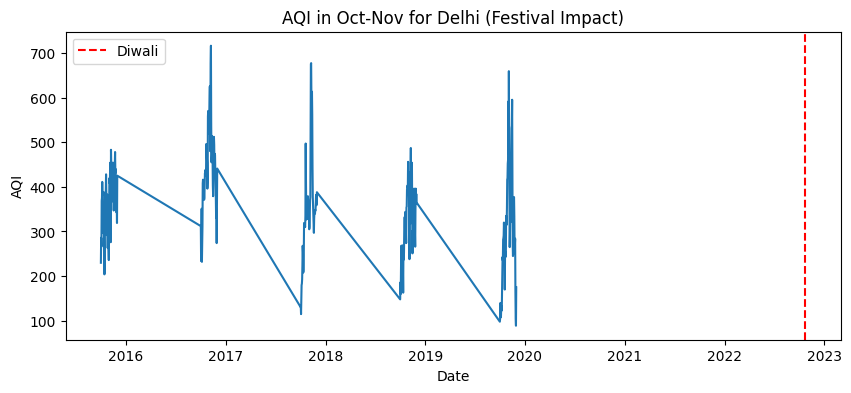

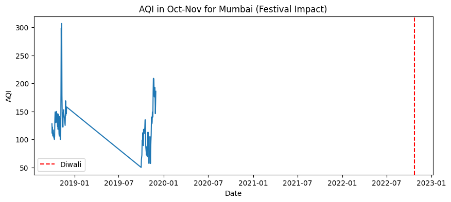

```python
fest_df = df[df['Date'].dt.month.isin([10, 11])]

for city in ['Delhi', 'Mumbai']:
    city_data = fest_df[fest_df['City'] == city]
    plt.figure(figsize=(10, 4))
    sns.lineplot(data=city_data, x='Date', y='AQI')
    plt.title(f"AQI in Oct-Nov for {city} (Festival Impact)")
    plt.axvline(pd.Timestamp('2022-10-24'), color='red', linestyle='--', label='Diwali')
    plt.legend()
    plt.show()
```

# Tableau Dashboard: Air Quality Trends (2015–2020)

This dashboard was built in Tableau to visualize air quality trends across Indian cities between 2015 and 2020.  
It includes interactive charts for AQI, pollutant levels, and seasonal patterns.

** View Dashboard Online:**  
[Click here to open on Tableau Public](https://public.tableau.com/app/profile/priya.kumari1330/viz/AnalyzingandPredictingAirQualityinIndianCities2/Homepage)

** Dashboard Preview:**

[figure not shown]